# Sparse generalized Dirichlet distributions for high-dimensional probabilities

Jyotishka Datta

July 10, 2019

# 1 Introduction

**This is an example page for showing some basic properties of this new class of distribution, to be accompanied by a paper that is yet to be written.**

The standard Dirichlet distribution is not equipped to handle many categories situation where some categories could be very rare, resulting in low frequencies. We propose a new generalization of the Dirichlet distribution that will adapt to sparsity without letting go of any of the nice distributional properties.

This document will define the prior and provide the basic R code for sampling from the sparse generalized Dirichlet distribution. The more advanced topics of posterior sampling (using Gibbs) and selected simulation studies are presented in the following documents.

1. Gibbs sampling
2. Real Data

# 2 Sparse generalized Dirichlet

## 2.1 Main idea

Our goal is to introduce sparsity without over-parametrizing the model and yet retaining the convenient properties such as conjugacy and neutrality of the usual Dirichlet-Multinomial set-up. Towards this, we first define the $f$-generalized Dirichlet ($f$-GD, henceforth) class of distributions using a stick-breaking construction as follows. Define $\pi \sim f\text{-GD}(\alpha, \gamma, \phi)$ if,

$$\begin{gather}
Z_k \sim f\left(\alpha, \phi_k, \gamma \right), \; Z_k \in (0,1), \; \alpha, \gamma, \phi_k \in \mathbb{R}^+ \label{eq:sparse-sb-1}\\
\pi_k = Z_k \prod_{l=1}^{k-1} (1 - Z_l), \; k = 1, \ldots, K-1, \text{and} \; \pi_K = 1 - \sum_{k=1}^{K-1} \pi_k \label{eq:sparse-sb}.
\end{gather}$$

Here, $f(\cdot)$ is a density supported on the unit interval, ideally one that lends additional flexibility to adapt to sparsity in the data. The hyper-parameters are as follows: $\alpha$ is a shape parameter, $\phi_k$ is a shrinkage parameter for the $k^{th}$ component $Z_k$, possibly depending on $Z_{-k}$, and $\gamma$ can be thought of as a nuisance parameter handling other distributional properties.

A natural choice is the Gauss hypergeometric prior proposed by Datta and Dunson for quassi-sparse count data:
$$f(\pi \mid a, b, \phi, \gamma) \propto \pi^{a-1} (1-\pi)^{b-1} ( 1 + (\phi - 1) \pi )^{-\gamma}, \; a >0, b >0, \gamma >0.$$

This class contains the standard Beta prior for $\phi = 1$ and the three-parameter Beta prior for $\gamma = a + b$. The result is a SGD distribution with parameters $a, b, \phi$ and $\gamma$, denoted as ${\rm sgd}(a, b, \phi, \gamma)$:
$$\pi \sim sgd(a, b, \phi, \gamma) \; \Leftrightarrow \;Z_k \sim f = \text{GH}\left(a_k, b_k, \phi_k, \gamma \right), \; a_k, b_k, \gamma, \phi_k \in \mathbb{R}^+.$$

The most general version of ${\rm sgd}(a, b, \phi, \gamma)$ will have $4K$ hyper-parameters for $K$ categories, which is prone to run into identifiability and overfitting issues in applications. To reduce the parametric complexity, we show the density for a special case below that retains all the desirable properties.

### 2.1.1 Simplest Sparse Prior

Let $\pi \sim { \rm sgd}(a,b,\phi,\gamma)$ with $a_i = \alpha (1 - i/K)$ and $b_i = \alpha/K$, $\gamma_i = a_i + b_i$, and $\phi_i - 1 = (\phi - 1)(1 - S_{i-1})$ for $\alpha, \phi > 0$, then the density for $\pi$ is:
$$\begin{align}
f(\pi \mid \alpha, \phi) & \propto \pi_1^{\frac{\alpha}{K} - 1} \cdots \pi_K^{\frac{\alpha}{K} - 1} \prod_{i=1}^{K-1} \left\{ 1 + (\phi - 1) \pi_i \right\}^{-\{\alpha(1- \frac{i}{K}) - 1\}}, \; \label{eq:sparse-sb-spcl}
\end{align}$$

## 2.2 Shape of the prior

We’ll first show how to sample from this prior using the stick breaking construction outlined above and then plot it.

### 2.2.1 Three-parameter Beta

Here we show the sampling scheme for the sparse generalized Dirichlet for a three-paarmeter Beta prior used to generate the broken stick lengths, instead of a beta. The first plot shows how the density concentrates near the origin for smaller values of $\phi$ but tends to uniformity with $\phi \to 1$, which recovers the symmetric Dirichlet.

```r
rtpb <- function(n, a, b , phi){
  # phi <- abs(rcauchy(1))
  lambda <- rgamma(n, a, phi)
  tau <- rgamma(n, b,  lambda)
  return(1/(1+tau))
}

rconmos <- function(n,K,alpha, phi)
{
  p <- matrix(0,n,K)
  # phi <- abs(rcauchy(1))
  for(i in 1:n){
    Z <- sapply(1:K, function(i) rtpb(1, alpha/K, alpha*(1-i/K), phi))
    p[i,1] <- Z[1]
    p[i,2:K] <- sapply(2:K, function(i) Z[i] * prod(1 - Z[1:(i-1)]))
  }
  return(p)
}
```

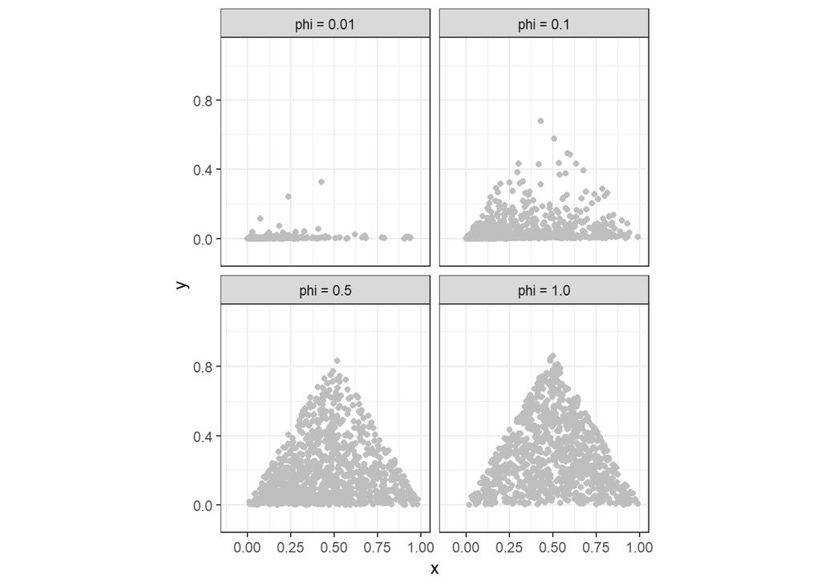

## 2.3 Effect of $\phi$

The parameter $\phi$ in controls the amount of shrinkage in the tails. We prove this phenomenon formally in our paper but reproduce the plot here for demonstration.

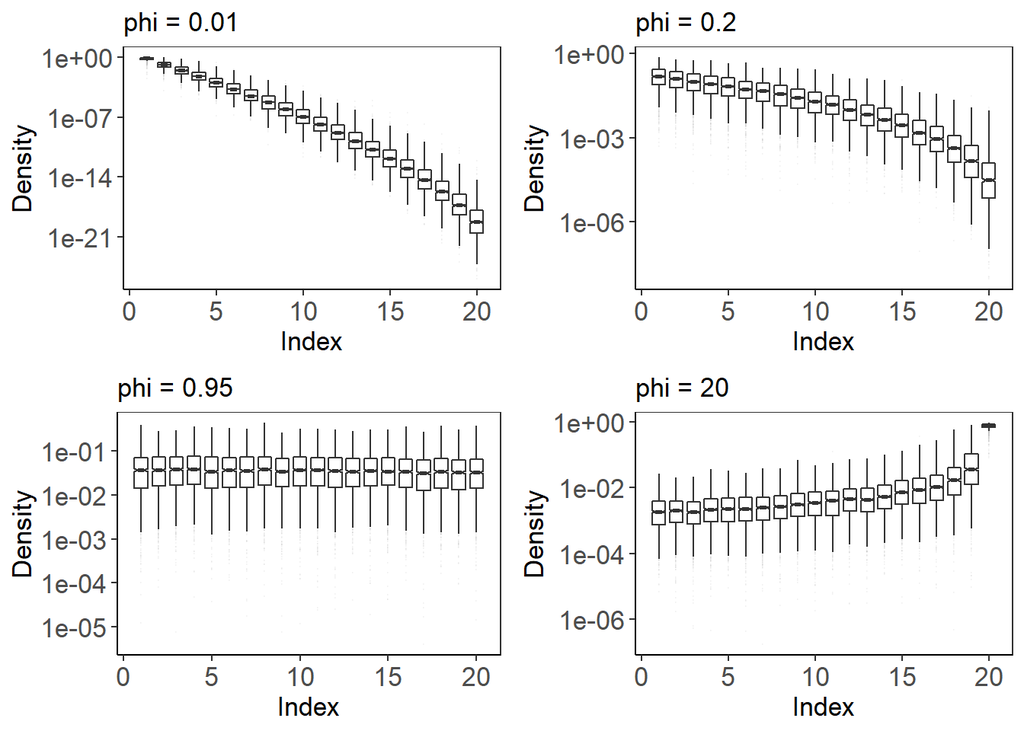

## 2.4 Dependence structure

The sparse generalized Dirichlet distribution has a more general dependence structure compared to the standard Dirichlet where all pairwise correlations are negative. We show this below via a numerical example by plotting the correlation heatmaps for the SGD distribution and the Dirichlet for the same $\alpha$. The SGD samples used here correspond to a smaller value of $\phi = 0.1$.

The correlation heatmap for SGD shows a more general dependence structure compared to the Dirichlet, as claimed above.

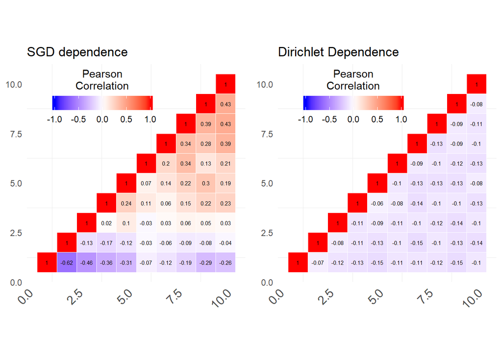